# Figure 3: High concentrations of CHG reduce the likelihood of colonization, but are rarely achieved

Diana Proctor

03/26/220

last updated: February 22 2021

**draft: submission to Nature Medicine October 2020**

*Manuscript Title*: Integrated genomic, epidemiologic investigation of Candida auris skin colonization

*Authors*: Diana M Proctor1, Thelma Dangana2, D. Joseph Sexton3, Christine Fukuda2, Rachel D Yelin2, Mary Stanley2, Pamela B Bell2, Sangeetha Baskaran2, Clay Deming1, Qiong Chen1, Sean Conlan1, NISC Comparative Sequencing Program4, Rory M Welsh3, Snigdha Vallabhaneni3,5, Tom Chiller3, Kathleen Forsberg3, Stephanie R. Black6, Massimo Pacilli6, Heidi H Kong7, Michael Y Lin2, Michael E Schoeny8, Anastasia P Litvintseva3, Julia A Segre1+, Mary K Hayden2+

*Affiliations*:

- 1Microbial Genomics Section, Translational and Functional Genomics Branch, National Human Genome Research Institute, National Institutes of Health, Bethesda, MD 20892, USA
- 2 Department of Internal Medicine, Division of Infectious Diseases, Rush University Medical Center, Chicago, IL 60612, USA.
- 3Mycotic Diseases Branch, Centers for Disease Control and Prevention, Atlanta, GA 30333, USA.
- 4NIH Intramural Sequencing Center, National Human Genome Research Institute, National Institutes of Health, Bethesda, MD 20892, USA.
- 5Division of Healthcare Quality Promotion, NCEZID, CDC, USA
- 6Communicable Disease Program, Chicago Department of Public Health, Chicago, IL, 60612, USA.
- 7Dermatology Branch, National Institute of Arthritis and Musculoskeletal and Skin Diseases, National Institutes of Health, Bethesda, MD 20892, USA
- 8College of Nursing, Rush University, Chicago, IL 60612, USA.
- +Contributed equally

### Description of the dataset

Here, we seek to examine the impact of CHG on the microbiome, as well as levels of variation in CHG concentration by body site. We have CHG concentrations for the first time point at each body site (Ic, An, Fg, Ax, Ne, Tw). We also have the bacterial and fungal data tables, which includes 365 taxa across 1115 samples.

To accomplish this, we read in the following data:

1. bac_match.rds
2. its_match.rds
3. sitecode_to_factored_sites.csv
4. Cauris_Analytic_2020-5-20.csv
5. CHG_oddsRatios_Schoeny.csv (not provided)

### Here, we render the following figures:

- Figure 3

Footnote: The logistic mixed effects model presented in Panel B, and embedded within data object 5 in the list above, was performed by M. Schoeny at Rush University. The code to render the figure is presented here, but the analysis itself was conducted in SAS.

```r
#set global knitting options
knitr::opts_chunk$set(echo = TRUE, warning = FALSE, message = FALSE, error = FALSE, fig.width = 6, fig.height = 5)
```

```r
# load package method from from Dan Sprokett

# set seed
set.seed(78979)
#define packages
packages <- c("knitr",
              "ggplot2",
              "scales",
              "ggeffects",
              "lme4",
              "stringr",
              "RColorBrewer",
              "gridExtra",
              "phyloseq",
              "dabestr",
              "tidyr",
              "dplyr",
              "purrr",
              "ggpubr",
              "ggrepel",
              "broom.mixed",
              "lmerTest",
              "cowplot",
              "reshape2")

# install packages from bioconductor
BiocManager::install(setdiff(packages,installed.packages()), update=FALSE)
n <- length(packages) - sum(sapply(packages,require,character.only=TRUE))

# print if packages loaded properly
if(n == 0){
  print("All necessary R packages loaded properly")
} else {
  print(paste0(n, " R packages did not load properly"))
}
```

```
## [1] "All necessary R packages loaded properly"
```

Define functions and then read in the data

```r
pal_freiburg_info <- c("#2a6ebb", "#a7c1e3", "#7b2927", "#de3831", "#739600", "#92d400",
                       "#4d4f53", "#747678", "#b2b4b3", "#d5d6d2", "#e98300", "#efbd47")

ISU_secondary_palette <- c("#3E4827", "#76881D", "#A2A569",
                           "#003D4C", "#006BA6", "#7A99AC",
                           "#7C2529", "#9A3324", "#BE531C",
                           "#8B5B29", "#B9975B", "#EED484",
                           "#6E6259", "#707372", "#ACA39A", "#C8102E")

ISU_primary_palette   <- c("#C8102E", "#F1BE48", "#524727",
                           "#9B945F", "#CAC7A7")

#define color palettes
set.seed(1009)
n <- 50
qual_col_pals = brewer.pal.info[brewer.pal.info$category == 'qual',]
col_vector = unlist(mapply(brewer.pal, qual_col_pals$maxcolors, rownames(qual_col_pals)))
```

Read in the data

```r
bac_match = readRDS(file="~/Desktop/candida_auris_rush/merged_16s_bac_match_cauris_clinical_map_withsqrt_withtree_withcoo_2020-03-19.rds")
merged_16s = readRDS(file="~/Desktop/candida_auris_rush/merged_16s_nonglom_cauris_clinical_map_withsqrt_withtree_withcoo_2020-03-19.rds")
its_match = readRDS(file="~/Desktop/candida_auris_rush/merged_its_its_match3_2020-04-02.rds") %>%
      subset_taxa(., Highest.Rank != "Less_than_10_per_ASV Less_than_10_per_ASV") %>%
      subset_taxa(., Highest.Rank != "Fungal sp.")

sites =  read.csv("~/Desktop/candida_auris_rush/sitecode_to_factored_sites.csv")
full.dat = read.csv("~/Desktop/candida_auris_rush/manuscript/data/Cauris_Analytic_2020-5-20.csv") %>%
  dplyr::select(., c("Unique_ptid", "Survey_Period", "Cauris_Result",
                     "site", "chg_conc", "CFUTotal_Cauris", "chgswab", "CFUTransform_Cauris"))  %>%
  plyr::join(., sites)
```

### Figure 3A: Let's look at chg concentration as a function of body site

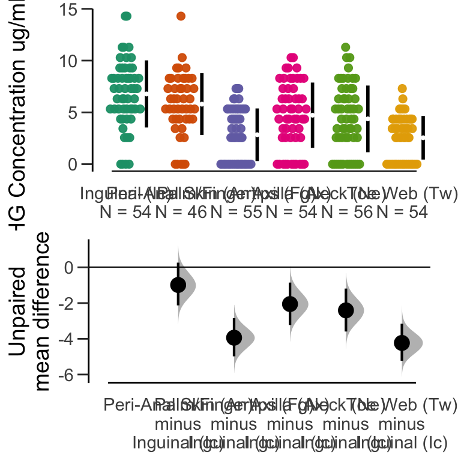

```r
full.dat$complete = complete.cases(full.dat$chg_conc)
full.dat = subset(full.dat, complete==TRUE)
full.dat$CFUTransform_Cauris[is.na(full.dat$CFUTransform_Cauris)] <- 0
full.dat$group = paste0(full.dat$Unique_ptid, ";", full.dat$SiteID)
full.dat$`CHG Concentration ug/mL (log2)` = log2(1+full.dat$chg_conc)

t1 = subset(full.dat, Survey_Period==1)
Figure3A <- dabestr::dabest(t1, Site.Extended, `CHG Concentration ug/mL (log2)` ,
                             idx=c("Inguinal (Ic)", "Peri-Anal Skin (An)",  "Palm/Fingertips (Fg)",
                                   "Axilla (Ax)", "Neck (Ne)" , "Toe Web (Tw)" ),
                             paired = FALSE) %>%
                      mean_diff()

plot(Figure3A, palette = "Dark2")
```

```r
ggsave(plot(Figure3A, palette = "Dark2"), file="~/Desktop/proctor_manuscript/Figure3/Figure3a.pdf", device="pdf",
       width = 12, height = 8)
```

### Figure3B: Plot the logistic mixed effects model from Michael Schoeny

Each point represents the odds of C. auris colonization from a logistic mixed effects model plotted against CHG concentration (ug/mL). Error bars encompass 95% confidence intervals. The solid horizontal lines demarcate the odds of colonization per respective group while the dashed lines encompass the 95% CI surrounding each estimate.

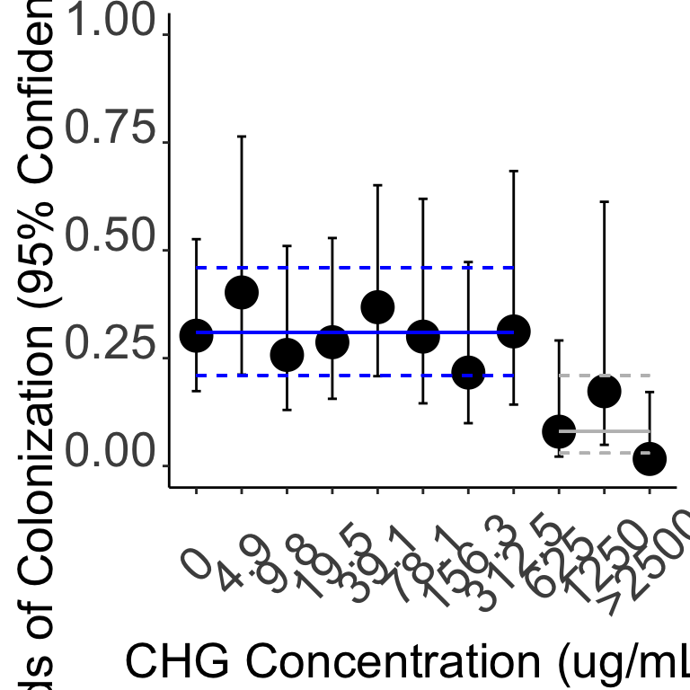

```r
dat = read.csv("~/Desktop/candida_auris_rush/manuscript/CHG_oddsRatios_Schoeny.csv")
dat$foo = dat$CHG
dat$foo = ifelse(dat$foo==">2500", 2500, dat$CHG)
ordering = unique(dat$CHG)
dat$CHG  <- factor(dat$CHG, levels = ordering)



y1 = mean(subset(dat, CHG %in% c("625", "1250", ">2500"))$Odds)
y2 = mean(subset(dat, CHG %in% c("625", "1250", ">2500"))$Odds)

high = subset(dat, CHG %in% c("625", "1250", ">2500"))
high$start=615
high$end=">2500"
low = subset(dat, !(CHG %in% c("625", "1250", ">2500")))
low$start=0
low$end="313"

#generate the plot
Figure3B = ggplot(dat, aes(x =CHG, y = Odds)) + geom_point(size=6) +
        theme_classic() +
        geom_errorbar(aes(ymin=X95U.u, ymax=X95L.l), width=.2,
                 position=position_dodge(.9))  + xlab("") +
        ylim(0, 1) + xlab("CHG Concentration (ug/mL)") +
        ylab("Odds of Colonization (95% Confidence Intervals)")  +
  geom_segment(aes(x = "0", y = 0.31, xend = "312.5", yend = 0.31),
               colour="blue") +
  geom_segment(aes(x = "0", y = 0.21, xend = "312.5", yend = 0.21), linetype="dashed",
               colour="blue") +
  geom_segment(aes(x = "0", y = 0.46, xend = "312.5", yend = 0.46), linetype="dashed",
               colour="blue") +
  geom_segment(aes(x = "625", y = 0.08, xend = ">2500", yend = 0.08),
               colour="gray")+
  geom_segment(aes(x = "625", y = 0.03, xend = ">2500", yend = 0.03),
               linetype="dashed", colour="gray")+
  geom_segment(aes(x = "625", y = 0.21, xend = ">2500", yend = 0.21),
               linetype="dashed", colour="gray") +
  theme(axis.text.x = element_text( size = 20, angle = 45, hjust = .5, vjust = .5, face = "plain"),
        axis.text.y = element_text(size = 20, angle = 0, hjust = 1, vjust = 0, face = "plain"),
        axis.title.x = element_text( size = 20, angle = 0, hjust = .5, vjust = 0, face = "plain"),
        axis.title.y = element_text(size = 20, angle = 90, hjust = .5, vjust = .5, face = "plain"))

Figure3B
```

```r
ggsave(Figure3B, file="~/Desktop/proctor_manuscript/Figure3/Figure3b.pdf", device="pdf",
       width = 6, height = 6)
```

### Figure 3C

- The model: abundance ~ cauris chg_conc + SiteID + (1 | Unique_ptid/Survey_Period) +ϵ

Volcano plot of statistical significance (-Log adjusted P-value) against the regression coefficients from the linear mixed effects models. Each point represents a regression coefficient for a bacterial or fungal species. The vertical lines demarcate regression coefficients of -0.2 and 0.2. Species having Holm adjusted p-values < 0.05 are highlighted in green while non-significant taxa are in blue. Species exhibiting a positive association with CHG concentration (estimate > 0.2, Holm adjusted p < 0.05) include Providencia stuartii, Proteus mirabilis, Candida tropicalis, Saccharomyces cerevisiae and Morganella morganii. Species exhibiting a negative correlation with CHG (estimate < -0.2, Holm adjusted p < 0.05) include Staphylococcus pettenkoferi, Anaerococcus octavius, Malassezia slooffiae, and Campylobacter ureolyticus.

```r
#add a variable testing for nas in chg conc' we'll use this to subset the data
sample_data(bac_match)$chg_conc_yn = is.na(sample_data(bac_match)$chg_conc)
sample_data(its_match)$chg_conc_yn = is.na(sample_data(its_match)$chg_conc)

#get rid of the tree - bacteria
otus = otu_table(bac_match)
map = sample_data(bac_match)
tax = bac_match@tax_table@.Data
bac_match = merge_phyloseq(otus, map, tax_table(tax))

#get rid of the tree - fungal
otus = otu_table(its_match)
map = sample_data(its_match)
tax = its_match@tax_table@.Data
its_match = merge_phyloseq(otus, map, tax_table(tax))


#subset the its table to eliminate noisy taxa; otherwise model fails
library(DESeq2);library(genefilter)
filtergroup = genefilter::filterfun(genefilter::kOverA(k=20, A=10)) #k = number of samples; A = abundance
#filter  taxa
        filtPhy = filter_taxa(its_match, filtergroup, prune=TRUE)
        filtPhy = prune_taxa(taxa_sums(filtPhy) > 0, filtPhy)
        filt_its = subset_samples(filtPhy, Unique_ptid != 32)

#generate a combined fungal/bacterial table so we can adjust pvalues in the regression appropriately
#get the number of taxa
phy = merge_phyloseq(bac_match, filt_its)
ntaxa(phy)
```

```
## [1] 365
```

```r
nsamples(phy)
```

```
## [1] 1115
```

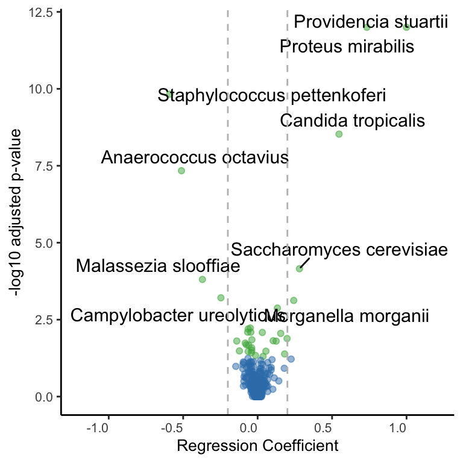

```r
#subset the phyloseq object on samples with chg conc, specific sites shown in panel a, and clr transform
chgPhy= subset_samples(phy, chg_conc_yn =="FALSE") %>%
  transform_sample_counts(., function(x) compositions::clr(x)) %>%
  subset_samples(., SiteID %in% c("Tw", "Fg", "Ic", "An", "Ax"))


set.seed(78927)
#make a map for the regression
map = data.frame(sample_data(chgPhy)) %>%
  dplyr::select(., c("chg_conc", "Unique_ptid", "SiteID", "Survey_Period"))

#log transform chg conc
map$chg_conc = log2(1+map$chg_conc)

#convert site and survey period to numeric
map$SiteID = as.numeric(factor(map$SiteID))
map$Survey_Period = as.numeric(as.character(map$Survey_Period))
map = data.frame(scale(map))

#get the otu table of the centered log ratio table
otus = data.frame(otu_table(chgPhy))

attach(map)
all=data.frame(cbind(otus, map))

#set up empty lists
mod <- list()
out <- list()
adjp <- list()

#https://stackoverflow.com/questions/57590176/adjust-p-values-obtained-with-lmertestlmer-for-multiple-comparisons
adjMC <- function( model_name ) {
  model_glht <- glht(model_name)
  model_MCadj <- summary(model_glht, test = adjusted('holm')) # Bonferroni-Holm
  return(model_MCadj)
}

library(multcomp)
for(i in names(otus)[-1]){
  mod[[i]] <- lmerTest::lmer(get(i) ~ chg_conc  + SiteID +
                               (1 | Unique_ptid / Survey_Period  ),
      data = all)
  adjp[[i]]  = adjMC(mod[[i]])
  out[[i]] = broom.mixed::tidy(adjp[[i]], conf.int = TRUE, .name_repair = "unique")
}
keep = colnames(bac_match@tax_table@.Data)[1:8]
tax = data.frame(filt_its@tax_table@.Data) %>%
  dplyr::select(., all_of(keep))
out = out %>% map_dfr(~ .x %>% as_tibble(), .id = "Highest.Rank")
out$Highest.Rank = str_replace_all(out$Highest.Rank, "([.])", " ")

df = data.frame(out) %>%
  plyr::join(tax) %>%
  subset(., contrast=="chg_conc")

tax.df = df

#make a volcano plot
pal <- brewer.pal(n = 4, name = 'Set1')
df$adj.p.value = as.numeric(as.character(df$adj.p.value))
my.annotation = subset(df, adj.p.value  < 0.05)
keepers = c("Staphylococcus pettenkoferi",
    "Anaerococcus octavius",
    "Malassezia slooffiae",
    "Campylobacter ureolyticus",
    "Morganella morganii",
    "Saccharomyces cerevisiae",
    "Candida tropicalis",
    "Proteus mirabilis",
    "Providencia stuartii")

df$Highest.Rank = as.character(as.factor(df$Highest.Rank))
df$neglog = -log10(df$adj.p.value)
df$neglog  = ifelse(df$neglog=="Inf", 12, df$neglog)

## Create a column to indicate which genes to label
df$species.label = ifelse(df$Highest.Rank %in% keepers, "TRUE", "FALSE")
df$significance = ifelse(df$adj.p.value < 0.05, "significant", "not")
myannotations = subset(df, species.label==TRUE & estimate > 0.2 | estimate < -0.2)

#plot figure 3c
Figure3C = ggplot(df) +
  geom_point(aes(x = estimate, y = neglog,
                                          color=significance), alpha=0.5) +
  geom_text_repel(data=myannotations, aes(x = estimate, y = neglog, label = Highest.Rank),size=4) +
  xlab("Regression Coefficient") +
  ylab("-log10 adjusted p-value")  +
  xlim(-1.2, 1.2)  +
  geom_vline(xintercept = -0.2, linetype='dashed', color="gray") +
  geom_vline(xintercept = 0.2, linetype='dashed', color="gray") +
  theme_classic() +
  scale_color_manual(values=c("#377EB8" ,"#4DAF4A"))+
    theme(text = element_text(size=10),
        axis.text.x = element_text(angle=0, hjust=1)) + theme(legend.position = "none") +
  scale_y_continuous(label=comma)

Figure3C
```

```r
ggsave(Figure3C, file="~/Desktop/candida_auris_rush/manuscript/NatureMedicine_revision/Figure3c.pdf", device="pdf",
       width = 10, height = 10)
```

#### Figure 3d

Let's look at the taxa with significant coefficients. We'll plot abundance vs. CHG concentration.

```r
keep = filter(df, adj.p.value < 0.05) %>%
  filter(., estimate > 0.25 | estimate < -0.25 )
keep.names = str_replace_all(keep$Highest.Rank, "([.])", " ")

sigPhy = prune_taxa(keep.names, chgPhy) %>%
  subset_samples(., abx_rx %in% c(0, 1))  %>%
  prune_samples(sample_sums(.) > 0, .)


df = data.frame(otu_table(sigPhy), sample_data(sigPhy)) %>%
  melt(., id.vars=colnames(sample_data(sigPhy)))
foo = colsplit(df$variable, "(.)", c("Genus", "Species"))
df = data.frame(cbind(df, foo))
df = subset(df, value !=0)

Figure3D = ggplot(df, aes(as.factor(chg_conc), value, color=variable, group=variable)) + geom_point() +
  facet_wrap(~variable, scales="free") + geom_smooth(method="lm") +
  theme_classic() + theme(legend.position = "none")+
  theme(axis.title.x=element_blank(),
        axis.text.x=element_blank(),
        axis.ticks.x=element_blank()) + scale_y_log10()


ggsave(Figure3D, file="~/Desktop/candida_auris_rush/manuscript/NatureMedicine_revision/Figure3d.pdf", device="pdf",
       width = 10, height = 10)
```

Repeat this analysis but this time use an even more stringent filter

```r
#add a variable testing for nas in chg conc' we'll use this to subset the data
sample_data(bac_match)$chg_conc_yn = is.na(sample_data(bac_match)$chg_conc)
sample_data(its_match)$chg_conc_yn = is.na(sample_data(its_match)$chg_conc)

#get rid of the tree - bacteria
otus = otu_table(bac_match)
map = sample_data(bac_match)
tax = bac_match@tax_table@.Data
bac_match = merge_phyloseq(otus, map, tax_table(tax))

#get rid of the tree - fungal
otus = otu_table(its_match)
map = sample_data(its_match)
tax = its_match@tax_table@.Data
its_match = merge_phyloseq(otus, map, tax_table(tax))


#subset the its table to eliminate noisy taxa; otherwise model fails
library(DESeq2);library(genefilter)
filtergroup = genefilter::filterfun(genefilter::kOverA(k=20, A=10)) #k = number of samples; A = abundance
#filter  taxa
        filtPhy = filter_taxa(its_match, filtergroup, prune=TRUE)
        filtPhy = prune_taxa(taxa_sums(filtPhy) > 0, filtPhy)
        filt_its = subset_samples(filtPhy, Unique_ptid != 32)

#generate a combined fungal/bacterial table so we can adjust pvalues in the regression appropriately
#get the number of taxa
phy = merge_phyloseq(bac_match, filt_its)
ntaxa(phy)
```

```
## [1] 365
```

```r
nsamples(phy)
```

```
## [1] 1115
```

```r
top50 = names(sort(taxa_sums(phy), TRUE)[1:50])
phy50 = prune_taxa(top50, phy) %>%
  prune_samples(sample_sums(.) > 0, .)
```

analysis on top 50 taxa

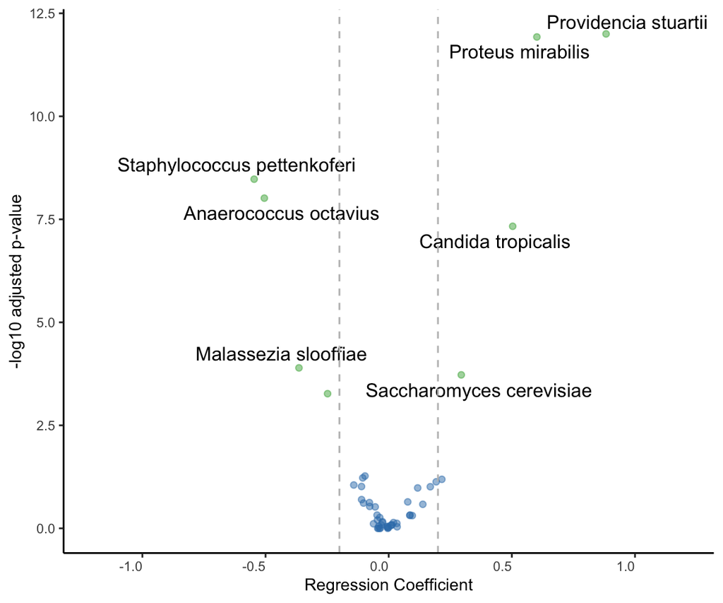

```r
#subset the phyloseq object on samples with chg conc, specific sites shown in panel a, and clr transform
chgPhy= subset_samples(phy50, chg_conc_yn =="FALSE") %>%
  transform_sample_counts(., function(x) compositions::clr(x)) %>%
  subset_samples(., SiteID %in% c("Tw", "Fg", "Ic", "An", "Ax"))


set.seed(78927)
#make a map for the regression
map = data.frame(sample_data(chgPhy)) %>%
  dplyr::select(., c("chg_conc", "Unique_ptid", "SiteID", "Survey_Period"))

#log transform chg conc
map$chg_conc = log2(1+map$chg_conc)

#convert site and survey period to numeric
map$SiteID = as.numeric(factor(map$SiteID))
map$Survey_Period = as.numeric(as.character(map$Survey_Period))
map = data.frame(scale(map))

#get the otu table of the centered log ratio table
otus = data.frame(otu_table(chgPhy))

attach(map)
all=data.frame(cbind(otus, map))

#set up empty lists
mod <- list()
out <- list()
adjp <- list()

#https://stackoverflow.com/questions/57590176/adjust-p-values-obtained-with-lmertestlmer-for-multiple-comparisons
adjMC <- function( model_name ) {
  model_glht <- glht(model_name)
  model_MCadj <- summary(model_glht, test = adjusted('holm')) # Bonferroni-Holm
  return(model_MCadj)
}

library(multcomp)
for(i in names(otus)[-1]){
  mod[[i]] <- lmerTest::lmer(get(i) ~ chg_conc  + SiteID +
                               (1 | Unique_ptid / Survey_Period  ),
      data = all)
  adjp[[i]]  = adjMC(mod[[i]])
  out[[i]] = broom.mixed::tidy(adjp[[i]], conf.int = TRUE, .name_repair = "unique")
}
keep = colnames(bac_match@tax_table@.Data)[1:8]
tax = data.frame(filt_its@tax_table@.Data) %>%
  dplyr::select(., all_of(keep))
out = out %>% map_dfr(~ .x %>% as_tibble(), .id = "Highest.Rank")
out$Highest.Rank = str_replace_all(out$Highest.Rank, "([.])", " ")

df = data.frame(out) %>%
  plyr::join(tax) %>%
  subset(., contrast=="chg_conc")

tax.df = df

#make a volcano plot
pal <- brewer.pal(n = 4, name = 'Set1')
df$adj.p.value = as.numeric(as.character(df$adj.p.value))
my.annotation = subset(df, adj.p.value  < 0.05)

df$Highest.Rank = as.character(as.factor(df$Highest.Rank))
df$neglog = -log10(df$adj.p.value)
df$neglog  = ifelse(df$neglog=="Inf", 12, df$neglog)

## Create a column to indicate which genes to label
df$significance = ifelse(df$adj.p.value < 0.05, "significant", "not")

#plot figure 3c
SupplementaryFigureTop50 = ggplot(df) +
  geom_point(aes(x = estimate, y = neglog,
                                          color=significance), alpha=0.5) +
  geom_text_repel(data=subset(df, adj.p.value < 0.05 & estimate > 0.25 | adj.p.value < 0.05 & estimate < -0.25)
                  , aes(x = estimate, y = neglog, label = Highest.Rank),size=4) +
  xlab("Regression Coefficient") +
  ylab("-log10 adjusted p-value")  +
  xlim(-1.2, 1.2)  +
  geom_vline(xintercept = -0.2, linetype='dashed', color="gray") +
  geom_vline(xintercept = 0.2, linetype='dashed', color="gray") +
  theme_classic() +
  scale_color_manual(values=c("#377EB8" ,"#4DAF4A"))+
    theme(text = element_text(size=10),
        axis.text.x = element_text(angle=0, hjust=1)) + theme(legend.position = "none") +
  scale_y_continuous(label=comma)

SupplementaryFigureTop50
```

```r
phy50Sig = subset_taxa(phy50, Highest.Rank %in% c("Providencia stuartii"   , "Proteus mirabilis",
                                                 "Staphylococcus pettenkoferi"  ,   "Anaerococcus octavius"  ,
                                                 "Candida tropicalis"  , "Malassezia slooffiae"  , "Saccharomyces cerevisiae" ,
                                                 "Morganella morganii" ,"Campylobacter ureolyticus"  ))

df = data.frame(otu_table(phy50Sig), sample_data(phy50Sig)) %>%
  melt(., id.vars=colnames(sample_data(phy50Sig)))
df$corr.direction = ifelse(df$variable %in% c("Providencia.stuartii" , "Proteus.mirabilis", "Candida.tropicalis" ,
                                               "Saccharomyces.cerevisiae", "Morganella.morganii" ), "positive", "negative")



p = ggplot(df, aes(variable, value, fill=corr.direction)) + geom_boxplot() + scale_y_log10() + geom_point() +
  stat_compare_means(ref.group = "Providencia.stuartii")

p = ggplot(df, aes(corr.direction, value, fill=corr.direction)) + geom_boxplot() + scale_y_log10() + geom_point() +
  stat_compare_means()

p = ggplot(df, aes(value, fill=corr.direction)) + geom_histogram() + scale_x_log10()

#https://cran.r-project.org/web/packages/distributions3/vignettes/two-sample-z-test.html
negatives = subset(df, corr.direction="negative")
negatives$clr = compositions::clr(negatives$value)
positives = subset(df, corr.direction="positive")
positives$clr = compositions::clr(positives$value)

delta_0 <- 0

# by assumption
sigma_sq_1 <- 3
sigma_sq_2 <- 2

n_1 <- length(negatives)
n_2 <- length(positives)

# calculate the z-statistic
z_stat <- (mean(negatives$value) - mean(positives$value) - delta_0) /
  sqrt(sigma_sq_1 / n_1 + sigma_sq_2 / n_2)

z_stat
```

```
## [1] 0
```

[output not shown]

```r
library(distributions3)

Z <- Normal(0, 1)  # make a standard normal r.v.
1 - cdf(Z, 0.376) + cdf(Z, -0.376)
```

```
## [1] 0.7069169
```

```r
1 - cdf(Z, abs(z_stat)) + cdf(Z, -abs(z_stat))
```

```
## [1] 1
```

p

#### Render Figure 3

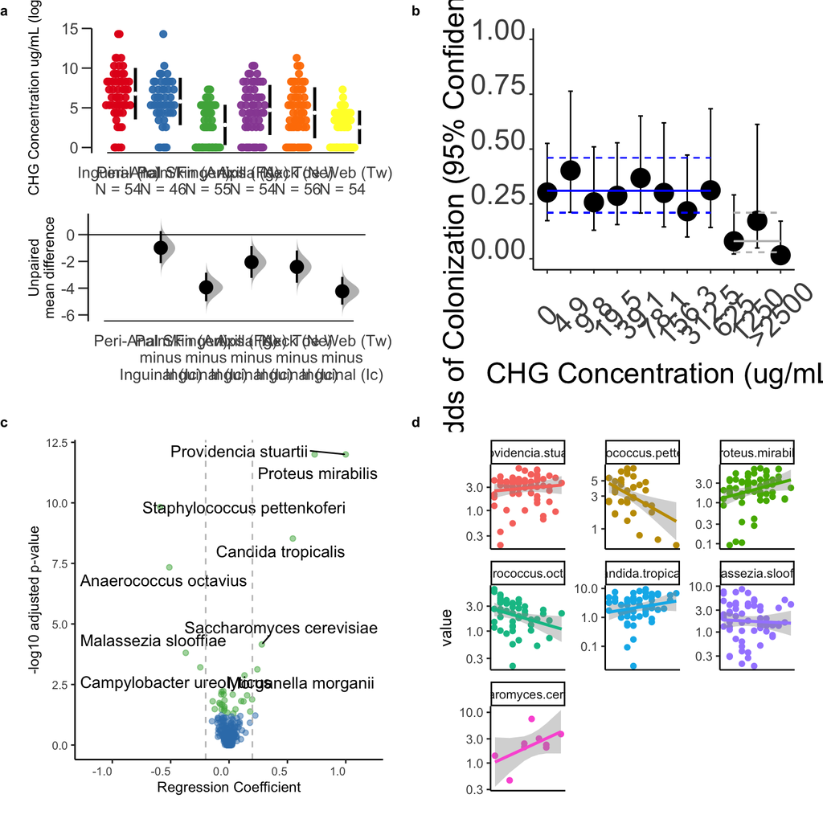

```r
cowplot::plot_grid(plot(Figure3A, axes.title.fontsize = 10), Figure3B, Figure3C,  Figure3D,
                   labels = "auto", label_size = 10, label_x = 0, hjust = 0, scale=0.9)
```

```r
ggsave(cowplot::plot_grid(plot(Figure3A, axes.title.fontsize = 10), Figure3B, Figure3C, Figure3D,
                   labels = "auto", label_size = 10, label_x = 0, hjust = 0, scale=0.9),
file="~/Desktop/candida_auris_rush/manuscript/NatureMedicine_revision/Figure3.pdf", device="pdf", width = 12, height = 10)
```